# BTRY6020 final project analysis

### Data visualizations

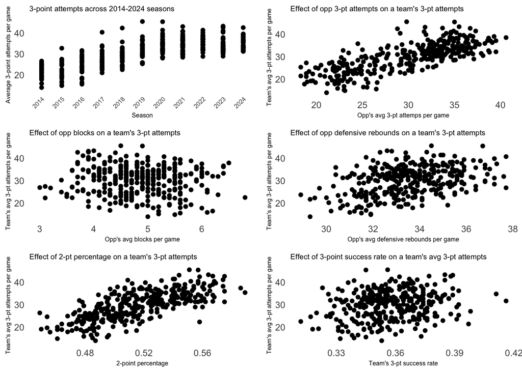

```r
library(ggplot2)
library(gridExtra)
vis1 <- ggplot(NBA_team_pg_data1424,aes(x=season, y=x3pa_per_game)) + geom_point(color="black") + theme_minimal() + theme(panel.grid = element_blank()) + labs(title="3-point attempts across 2014-2024 seasons", x="Season",y="Average 3-point attempts per game") + theme(axis.text.x = element_text(angle = 45, hjust=1, size=6)) + theme(title = element_text(hjust=0.5, size=6))

vis2 <- ggplot(NBA_team_pg_data1424,aes(x=opp_x3pa_per_game, y=x3pa_per_game)) + geom_point(color="black") + theme_minimal() + theme(panel.grid = element_blank()) + labs(title="Effect of opp 3-pt attempts on a team's 3-pt attempts", x="Opp's avg 3-pt attemps per game",y="Team's avg 3-pt attempts per game") + theme(title = element_text(hjust=0.5, size=6))

vis3 <- ggplot(NBA_team_pg_data1424,aes(x=opp_blk_per_game, y=x3pa_per_game)) + geom_point(color="black") + theme_minimal() +  theme(panel.grid = element_blank()) + labs(title="Effect of opp blocks on a team's 3-pt attempts", x="Opp's avg blocks per game",y="Team's avg 3-pt attempts per game") + theme(title =element_text(hjust=0.5, size=6))

vis4 <- ggplot(NBA_team_pg_data1424,aes(x=opp_drb_per_game, y=x3pa_per_game)) + geom_point(color="black") + theme_minimal() + theme(panel.grid = element_blank()) + labs(title="Effect of opp defensive rebounds on a team's 3-pt attempts", x="Opp's avg defensive rebounds per game",y="Team's avg 3-pt attempts per game") + theme(title = element_text(hjust=0.5, size=6))

vis5 <- ggplot(NBA_team_pg_data1424,aes(x=x2p_percent, y=x3pa_per_game)) + geom_point(color="black") + theme_minimal() + theme(panel.grid = element_blank()) + labs(title="Effect of 2-pt percentage on a team's 3-pt attempts", x="2-point percentage",y="Team's avg 3-pt attempts per game") + theme(title = element_text(hjust=0.5, size=6))

vis6 <- ggplot(NBA_team_pg_data1424,aes(x=x3p_percent, y=x3pa_per_game)) + geom_point(color="black") + theme_minimal() + theme(panel.grid = element_blank()) + labs(title="Effect of 3-point success rate on a team's avg 3-pt attempts", x="Team's 3-pt success rate",y="Team's avg 3-pt attempts per game") + theme(title = element_text(hjust=0.5, size=6))

grid.arrange(vis1, vis2, vis3, vis4, vis5, vis6, nrow=3, ncol=2)
```

## Regression assumptions verification

The assumptions for regression are:

- Linearity
- Normality of residuals
- Homoscedasticity (constant variance of residuals)
- Independence of observations
- Multicollinearity assessment

```r
#need to make the model first
x3pa.over.time.full.lm <- lm(x3pa_per_game ~ season + x2p_percent + x3p_percent + opp_x3pa_per_game + opp_blk_per_game + opp_drb_per_game, data=NBA_team_pg_data1424)
summary(x3pa.over.time.full.lm)
```

```
##
## Call:
## lm(formula = x3pa_per_game ~ season + x2p_percent + x3p_percent +
##     opp_x3pa_per_game + opp_blk_per_game + opp_drb_per_game,
##     data = NBA_team_pg_data1424)
##
## Residuals:
##     Min      1Q  Median      3Q     Max
## -7.3923 -2.3793  0.0104  2.1471 10.8780
##
## Coefficients:
##                     Estimate Std. Error t value Pr(>|t|)
## (Intercept)       -73.963797  10.315393  -7.170 5.39e-12 ***
## season2015          0.756779   0.840704   0.900 0.368718
## season2016          0.623295   0.880211   0.708 0.479396
## season2017          2.183148   0.984894   2.217 0.027364 *
## season2018          2.859189   1.104366   2.589 0.010074 *
## season2019          3.947162   1.324719   2.980 0.003111 **
## season2020          5.686623   1.453518   3.912 0.000112 ***
## season2021          5.667874   1.505107   3.766 0.000198 ***
## season2022          6.786728   1.531298   4.432 1.29e-05 ***
## season2023          5.459063   1.504241   3.629 0.000332 ***
## season2024          6.473749   1.566388   4.133 4.60e-05 ***
## x2p_percent        94.964298  11.203962   8.476 9.21e-16 ***
## x3p_percent        30.833253  13.290258   2.320 0.020982 *
## opp_x3pa_per_game   0.007273   0.088751   0.082 0.934740
## opp_blk_per_game    0.071002   0.331953   0.214 0.830770
## opp_drb_per_game    1.179723   0.141009   8.366 1.98e-15 ***
## ---
## Signif. codes:  0 '***' 0.001 '**' 0.01 '*' 0.05 '.' 0.1 ' ' 1
##
## Residual standard error: 3.212 on 314 degrees of freedom
## Multiple R-squared:  0.755,  Adjusted R-squared:  0.7433
## F-statistic:  64.5 on 15 and 314 DF,  p-value: < 2.2e-16
```

```r
library(car)
vif(x3pa.over.time.full.lm) #based on the values from this code it appears there is moderate multicollinearity with 2 predictors
```

```
##                        GVIF Df GVIF^(1/(2*Df))
## season            13.330801 10        1.138264
## x2p_percent        3.323619  1        1.823079
## x3p_percent        1.570745  1        1.253294
## opp_x3pa_per_game  7.615836  1        2.759680
## opp_blk_per_game   1.632400  1        1.277654
## opp_drb_per_game   1.811639  1        1.345972
```

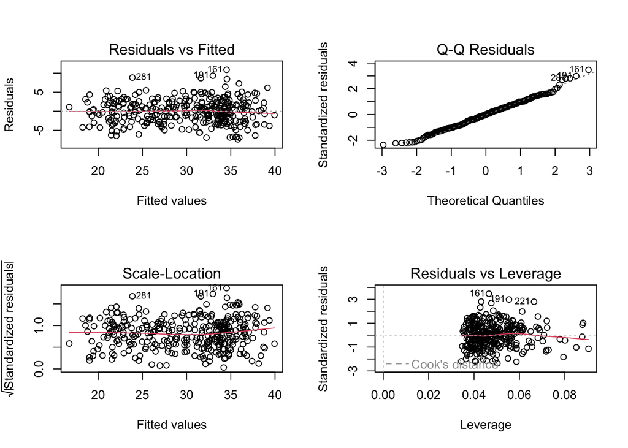

```r
par(mfrow=c(2,2))
plot(x3pa.over.time.full.lm)
```

```r
durbinWatsonTest(x3pa.over.time.full.lm) #no autocorrelation, p>0.05
```

```
##  lag Autocorrelation D-W Statistic p-value
##    1     -0.01402034      2.024984    0.75
##  Alternative hypothesis: rho != 0
```

Results from diagnostic plots:

- Based on the residuals vs. fitted plot, the assumption of linearity is met - points are mostly equally distributed around the horizontal line.
- Based on the Q-Q plot residuals plot, the residuals do look *approximately* normal - there is some deviation but not egregious.
- Based on the Durbin-Watson test, the assumption of independence of observations is met (p>0.05).
- Based on the scale-location plot, the assumption of homoscedasticity is met. Points appear to be mostly evenly spread.
- Based on the Variance Inflation Factor output, there is a moderate-high level of multicollinearity with the variable “opp_x3pa_per_game” and a mild-moderate level of multicollinearity with “x2p_percent.”

##Assumption violation handling - the only assumption being violated is multicollinearity

We should explore removing these variables. Our research question is “Some people say that the NBA has become too reliant on 3-point shots. How has the average number of 3pters per game (x3pa) changed over time and what factors influenced this variation?” So, the number of 3-point shots a team’s opponent is attempting might be serving as a sort of proxy for how the 3-point shot trends over time in the league. If we are assuming that the number of 3-point shot attempts increased across the league, it’s reasonable to assume it increases for both a team *and* their opponent, rendering the “opp_x3pa_per_game” predictor redundant. However, the success rate of 2-point shots might be relevant. I will also do backward selection using BIC and then LASSO to see if those reduced models are any better.

```r
#first remove x2p_percent and keep opp_x3pa_per_game and then run VIF
lm.no.x2p <- lm(x3pa_per_game ~ season + x3p_percent + opp_x3pa_per_game + opp_blk_per_game + opp_drb_per_game, data=NBA_team_pg_data1424)
vif(lm.no.x2p)
```

```
##                        GVIF Df GVIF^(1/(2*Df))
## season            10.708007 10        1.125863
## x3p_percent        1.556680  1        1.247670
## opp_x3pa_per_game  7.517563  1        2.741817
## opp_blk_per_game   1.376528  1        1.173255
## opp_drb_per_game   1.640179  1        1.280695
```

```r
#now remove opp_x3pa_per_game and keep x2p_percent and then run VIF
lm.no.oppx3p <- lm(x3pa_per_game ~ season + x2p_percent + x3p_percent + opp_blk_per_game + opp_drb_per_game, data=NBA_team_pg_data1424)
vif(lm.no.oppx3p)
```

```
##                      GVIF Df GVIF^(1/(2*Df))
## season           4.915380 10        1.082874
## x2p_percent      3.280731  1        1.811279
## x3p_percent      1.569502  1        1.252798
## opp_blk_per_game 1.607860  1        1.268014
## opp_drb_per_game 1.761999  1        1.327403
```

When “opp_x3pa_per_game” and “x2p_percent” are removed from the model, the VIF values improve for other predictors.

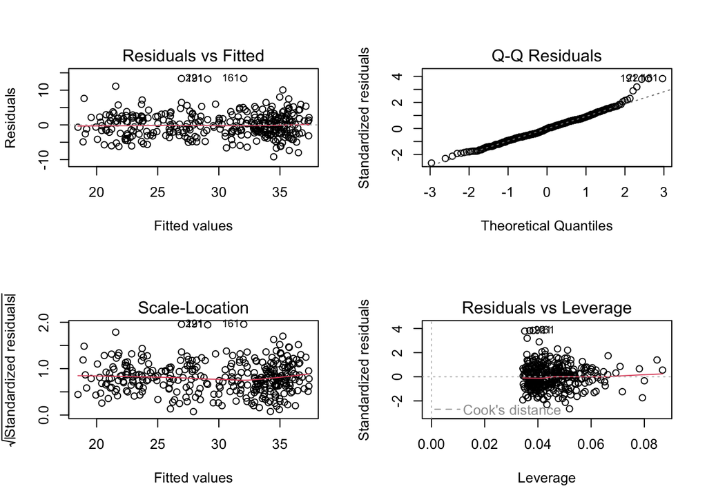

```r
#checking diagnostic plots again for each reduced model
par(mfrow=c(2,2))
plot(lm.no.x2p)
```

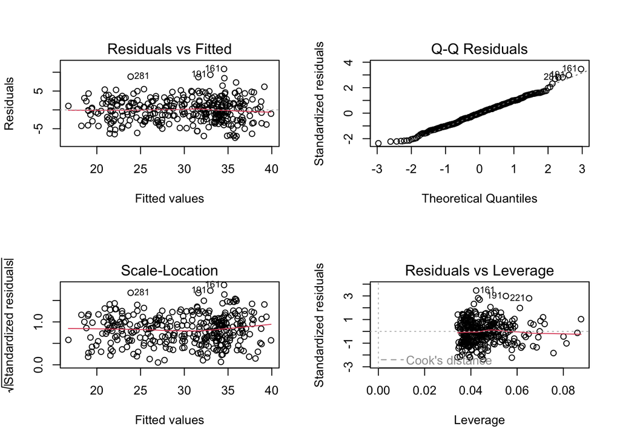

```r
plot(lm.no.oppx3p)
```

Not much has changed with the diagnostic plots. The next step will be to do backward selection and LASSO regularization on the full model to see if any predictors get eliminated that way.

###Variable selection In order to decide how to proceed with variable selection, it is important to think about the purpose of this model: understanding or predicting? For this particular question, we are interested in *understanding* the factors that may have influenced a change in the number of 3-point shots attempted per game over a 10-year period in the league. Using $R^2$ would not be a good idea since it increases as you add predictors to a model.

I think BIC would be a good choice here and I will use backwards selection because I already have a full model created and I am looking to check that, rather than build a model starting from the intercept. Because I still am not sure which variable to remove from before, I will run backward selection using BIC for both.

```r
#backward BIC from full original model
backward.bic.full.og.lm <- step(object=x3pa.over.time.full.lm, direction="backward", k=log(nrow(NBA_team_pg_data1424)))
```

```
## Start:  AIC=846.54
## x3pa_per_game ~ season + x2p_percent + x3p_percent + opp_x3pa_per_game +
##     opp_blk_per_game + opp_drb_per_game
##
##                     Df Sum of Sq    RSS    AIC
## - season            10    272.97 3512.5 815.24
## - opp_x3pa_per_game  1      0.07 3239.6 840.75
## - opp_blk_per_game   1      0.47 3240.0 840.79
## - x3p_percent        1     55.53 3295.1 846.35
## <none>                           3239.6 846.54
## - opp_drb_per_game   1    722.14 3961.7 907.15
## - x2p_percent        1    741.20 3980.8 908.73
##
## Step:  AIC=815.24
## x3pa_per_game ~ x2p_percent + x3p_percent + opp_x3pa_per_game +
##     opp_blk_per_game + opp_drb_per_game
##
##                     Df Sum of Sq    RSS    AIC
## - opp_blk_per_game   1      3.45 3516.0 809.77
## - x3p_percent        1     55.88 3568.4 814.65
## <none>                           3512.5 815.24
## - opp_x3pa_per_game  1    417.12 3929.7 846.48
## - opp_drb_per_game   1    930.64 4443.2 887.01
## - x2p_percent        1   1286.27 4798.8 912.41
##
## Step:  AIC=809.77
## x3pa_per_game ~ x2p_percent + x3p_percent + opp_x3pa_per_game +
##     opp_drb_per_game
##
##                     Df Sum of Sq    RSS    AIC
## - x3p_percent        1     53.00 3569.0 808.91
## <none>                           3516.0 809.77
## - opp_x3pa_per_game  1    503.83 4019.8 848.16
## - opp_drb_per_game   1    927.65 4443.6 881.24
## - x2p_percent        1   1431.48 4947.5 916.68
##
## Step:  AIC=808.91
## x3pa_per_game ~ x2p_percent + opp_x3pa_per_game + opp_drb_per_game
##
##                     Df Sum of Sq    RSS    AIC
## <none>                           3569.0 808.91
## - opp_x3pa_per_game  1    492.88 4061.9 845.80
## - opp_drb_per_game   1    876.85 4445.8 875.60
## - x2p_percent        1   1744.04 5313.0 934.41
```

```r
summary(backward.bic.full.og.lm) #ends at 808.91
```

```
##
## Call:
## lm(formula = x3pa_per_game ~ x2p_percent + opp_x3pa_per_game +
##     opp_drb_per_game, data = NBA_team_pg_data1424)
##
## Residuals:
##    Min     1Q Median     3Q    Max
## -8.280 -2.358  0.078  2.337 10.402
##
## Coefficients:
##                    Estimate Std. Error t value Pr(>|t|)
## (Intercept)       -79.20519    6.55927  -12.07  < 2e-16 ***
## x2p_percent       116.14450    9.20203   12.62  < 2e-16 ***
## opp_x3pa_per_game   0.34935    0.05207    6.71 8.64e-11 ***
## opp_drb_per_game    1.15352    0.12889    8.95  < 2e-16 ***
## ---
## Signif. codes:  0 '***' 0.001 '**' 0.01 '*' 0.05 '.' 0.1 ' ' 1
##
## Residual standard error: 3.309 on 326 degrees of freedom
## Multiple R-squared:  0.7301, Adjusted R-squared:  0.7276
## F-statistic: 293.9 on 3 and 326 DF,  p-value: < 2.2e-16
```

The lowest BIC (which is what we want) came from the full model being reduced to **x3pa_per_game ~ season + x2p_percent + opp_x3pa_per_game + opp_drb_per_game** - I put season back in since I want to investigate the trends over time.

```r
#making this into a model for comparison later
BIC.reduced.from.og.lm <- lm(x3pa_per_game ~ season + x2p_percent + opp_x3pa_per_game + opp_drb_per_game, data=NBA_team_pg_data1424)
```

For another variable selection technique, we can try a Lasso procedure because it shrinks coefficients to zero which effectively acts as variable selection. I will run this using the full original model to see if it has any insight with which variable to drop.

```r
library(glmnet)
```

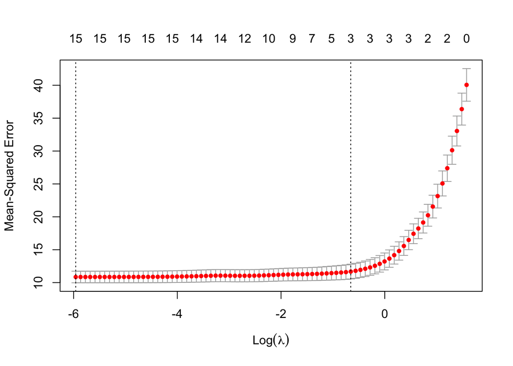

```r
#matrix for lasso, full original model
x <- model.matrix(x3pa_per_game ~ season + x2p_percent + x3p_percent + opp_x3pa_per_game + opp_blk_per_game + opp_drb_per_game, data=NBA_team_pg_data1424) [, -1]
y <- NBA_team_pg_data1424$x3pa_per_game
#run lasso
full.og.lasso.glm <- glmnet::cv.glmnet(x,y, alpha=1)
plot(full.og.lasso.glm, xvar="lamba", label=TRUE)
```

```r
coef(full.og.lasso.glm, s=full.og.lasso.glm$lambda.1se)
```

```
## 16 x 1 sparse Matrix of class "dgCMatrix"
##                            s1
## (Intercept)       -56.9484039
## season2015          .
## season2016          .
## season2017          .
## season2018          .
## season2019          .
## season2020          .
## season2021          .
## season2022          .
## season2023          .
## season2024          .
## x2p_percent        94.6146193
## x3p_percent         .
## opp_x3pa_per_game   0.3694177
## opp_blk_per_game    .
## opp_drb_per_game    0.8035929
```

```r
#create a model for comparison later
red.lasso.on.og.full.model <- lm(x3pa_per_game ~ season + x2p_percent + x3p_percent + opp_x3pa_per_game + opp_drb_per_game, data=NBA_team_pg_data1424)
```

Checking diagnostic plots for the reduced models created by BIC and by LASSO, diagnostic plots still look good & relatively the same between the two models

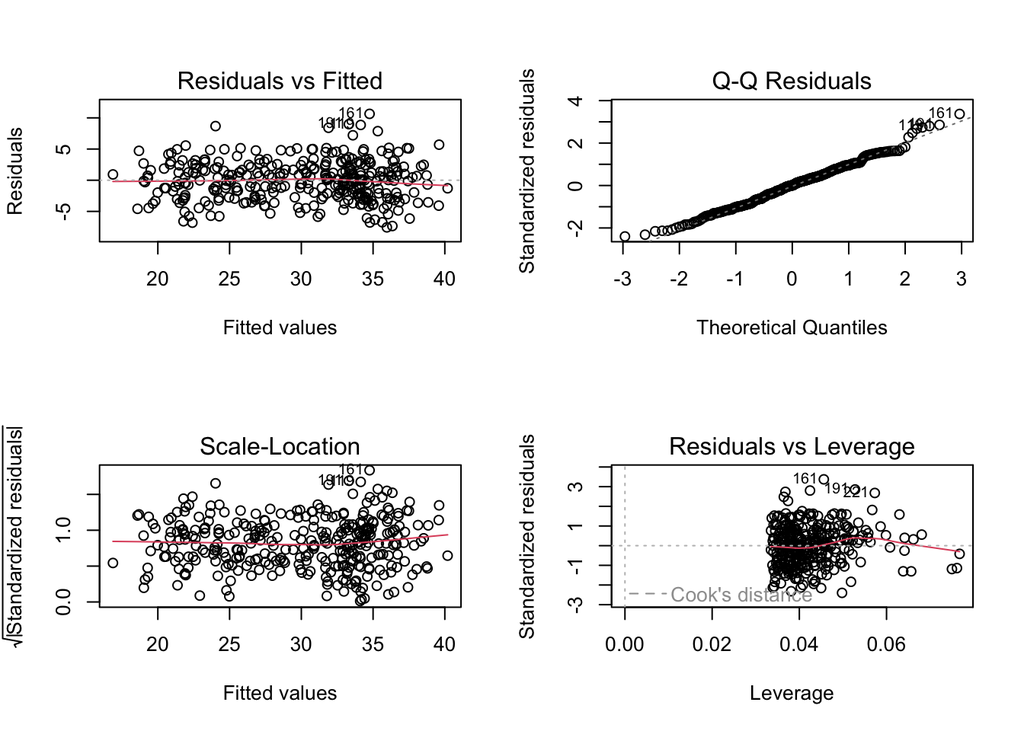

```r
par(mfrow=c(2,2))
plot(BIC.reduced.from.og.lm)
```